# 3.7 ANOVA

Author

Affiliation

Vladimir Buskin

Catholic University of Eichstätt-Ingolstadt

Abstract

This supplementary handout introduces one-way analysis of variance (ANOVA) for comparing the means of three or more groups, covering the decomposition of variance, the F-test, effect sizes, assumption checks and post-hoc comparisons with Tukey’s HSD test, using psycholinguistic data on verb polysemy.

## Recommended reading

> Kirk (1982: Chapter 5)

> Mendenhall et al. (1986: Chapter 13)

## Preparation

```r
library(readxl)
library(tidyverse)
library(effectsize) # for effect sizes

psycholing_data <- read_xlsx("psycholing_data.xlsx")
```

## Why ANOVA?

The $t$-test (see 3.6 t-test) only compares the means of **two** groups. For comparisons between **three or more groups**, analysis of variance (ANOVA) is the method of choice.

But couldn’t we simply run several $t$-tests, one for each pair of groups? With four groups, this would amount to six $t$-tests. The problem is that every single test comes with a 5% risk of a Type I error (see 3.4 Hypothesis testing). Across six tests, the probability of obtaining at least one false positive therefore rises to approximately $1 - 0.95^6 \approx 26\%$. ANOVA avoids this problem by testing all group means **simultaneously** in a single test.

## Data and hypotheses

The following dataset comprises various semantic and distributional measures for 407 transitive verbs. We will group the verbs into four frequency bins based on the quartiles of their frequency distribution: ‘low’, ‘moderate’, ‘high’ and ‘very high’.

```r
# Create frequency bins
psycholing_data <- psycholing_data %>%
  mutate(
    Frequency_bin = case_when(
      is.na(Frequency) ~ NA_character_, # keep missing values as missing
      Frequency <= quantile(Frequency, 0.25, na.rm = TRUE) ~ "low",
      Frequency <= quantile(Frequency, 0.50, na.rm = TRUE) ~ "moderate",
      Frequency <= quantile(Frequency, 0.75, na.rm = TRUE) ~ "high",
      TRUE ~ "very_high"
    ),
     # Convert to factor with proper ordering
    Frequency_bin = factor(Frequency_bin,
                          levels = c("low", "moderate", "high", "very_high"))
  )

# Show some examples
psycholing_data %>%
  select(Verb, Frequency_bin) %>%
  head(n = 10)
```

```
# A tibble: 10 × 2
   Verb       Frequency_bin
   <chr>      <fct>
 1 accelerate moderate
 2 accept     very_high
 3 accompany  low
 4 accumulate moderate
 5 acquire    high
 6 adore      low
 7 advance    low
 8 advise     high
 9 affect     high
10 alter      high
```

The column `Number_meanings` represents the number of distinct word senses listed in the [WordNet](https://wordnet.princeton.edu) database. We will examine whether the mean number of meanings $\mu$ differs across the four frequency bins:

- $H_0: \mu_{\text{low}} = \mu_{\text{moderate}} = \mu_{\text{high}} = \mu_{\text{very high}}$
- $H_1:$ At least one group mean differs from the others.

From a descriptive point of view, there is indeed some evidence that the number of meanings and frequency are linked:

```r
psycholing_data %>%
  group_by(Frequency_bin) %>%
  summarise(
    n = n(),
    mean_meanings = mean(Number_meanings, na.rm = TRUE),
    sd_meanings = sd(Number_meanings, na.rm = TRUE),
    median_meanings = median(Number_meanings, na.rm = TRUE),
    .groups = 'drop'
  )
```

```
# A tibble: 4 × 5
  Frequency_bin     n mean_meanings sd_meanings median_meanings
  <fct>         <int>         <dbl>       <dbl>           <dbl>
1 low             123          5.20        4.17               4
2 moderate         81          7.23        5.12               6
3 high            103         10.2         7.57               8
4 very_high       100         16.6        14.0               12
```

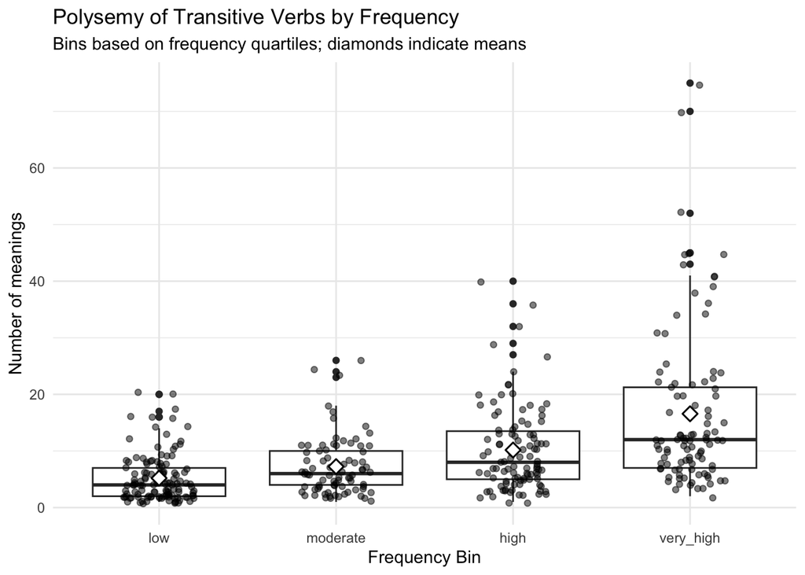

```r
ggplot(psycholing_data, aes(x = Frequency_bin, y = Number_meanings)) +
  geom_boxplot() +
  geom_jitter(width = 0.2, alpha = 0.5) +
  stat_summary(
    fun = mean,
    geom = "point",
    shape = 23,  # filled diamond
    size = 3,
    fill = "white",
    color = "black",
    stroke = 0.8
  ) +
  labs(
    title = "Polysemy of Transitive Verbs by Frequency",
    subtitle = "Bins based on frequency quartiles; diamonds indicate means",
    x = "Frequency Bin",
    y = "Number of meanings"
  ) +
  theme_minimal()
```

## The logic of ANOVA

Despite its name, ANOVA tests a hypothesis about **means**. It does so by comparing two sources of variability in the data:

- the variability **between** the groups, i.e., how far the group means lie from the overall mean, and
- the variability **within** the groups, i.e., how far the individual observations lie from their own group mean.

If the group means are truly equal ($H_0$), the differences between the group means should be no larger than what we would expect from the random variability within the groups.

**The maths behind ANOVA**

Let $y_{ij}$ denote the $j$-th observation in group $i$, $n_i$ the size of group $i$, $k$ the number of groups and $n = n_1 + n_2 + \dots + n_k$ the total sample size. Furthermore, let $\bar{y}$ denote the overall (grand) mean of all observations and $\bar{T}_i$ the sample mean of the $i$-th group.

The **total sum of squares** captures the overall variability of the data, i.e., the squared deviations of all observations from the grand mean:

$$\text{Total SS} = \sum_{i=1}^k \sum_{j=1}^{n_i} (y_{ij} - \bar{y})^2
\tag{1}$$

It can be split up into two components. The **sum of squares for treatments** (SST) captures the variability between the groups:

$$\text{SST} = \sum_{i=1}^k n_i(\bar{T}_i - \bar{y})^2
\tag{2}$$

The **sum of squares for error** (SSE) captures the variability within the groups:

$$\text{SSE} = \sum_{i=1}^k\sum_{j=1}^{n_i} (y_{ij} - \bar{T}_i)^2
\tag{3}$$

Crucially, $\text{Total SS} = \text{SST} + \text{SSE}$. Dividing each sum of squares by its degrees of freedom yields the **mean square for treatments** (MST) and the **mean square for error** (MSE):

$$\text{MST} = \frac{\text{SST}}{k-1}, \qquad \text{MSE} = \frac{\text{SSE}}{n-k}
\tag{4}$$

The test statistic is their ratio:

$$F = \frac{\text{MST}}{\text{MSE}}
\tag{5}$$

Under $H_0$, $F$ follows an $F$-distribution with $k-1$ and $n-k$ degrees of freedom and should be close to 1. The larger the differences between the group means relative to the variability within the groups, the larger $F$ becomes, and the smaller the $p$-value.

## ANOVA in R

R’s `aov()` function performs the $F$-test. Its syntax resembles that of `t.test()`: The dependent variable is placed to the left of the tilde `~` and the grouping variable to its right.

```r
anova_model <- aov(Number_meanings ~ Frequency_bin, data = psycholing_data)

summary(anova_model)
```

```
               Df Sum Sq Mean Sq F value Pr(>F)
Frequency_bin   3   7730  2576.5   35.17 <2e-16 ***
Residuals     403  29525    73.3
---
Signif. codes:  0 '***' 0.001 '**' 0.01 '*' 0.05 '.' 0.1 ' ' 1
```

The output contains the degrees of freedom (`Df`), the sums of squares (`Sum Sq`) and mean squares (`Mean Sq`) for the grouping variable (`Frequency_bin`, i.e., SST and MST) and the residuals (`Residuals`, i.e., SSE and MSE), followed by the $F$-value and the $p$-value.

**ANOVA and linear regression**

ANOVA is in fact a special case of the linear regression model with a categorical predictor (see 4.1 Linear regression). Fitting `lm(Number_meanings ~ Frequency_bin, data = psycholing_data)` yields exactly the same $F$-test, which can be found at the bottom of the `summary()` output.

### Effect size

As with the $t$-test, the $p$-value does not tell us how strong the effect is. A common effect size measure for ANOVA is $\eta^2$ (‘eta squared’), which indicates the proportion of the total variability that is accounted for by the grouping variable:

$$\eta^2 = \frac{\text{SST}}{\text{Total SS}}
\tag{6}$$

We can compute it with `eta_squared()` from the `effectsize` package:

```r
eta_squared(anova_model)
```

```
For one-way between subjects designs, partial eta squared is equivalent
  to eta squared. Returning eta squared.
```

```
# Effect Size for ANOVA

Parameter     | Eta2 |       95% CI
-----------------------------------
Frequency_bin | 0.21 | [0.15, 1.00]

- One-sided CIs: upper bound fixed at [1.00].
```

Note that `eta_squared()` reports a one-sided confidence interval by default, which is why its upper bound is always 1.

> According to a one-way ANOVA, there is a statistically significant effect of frequency on the number of meanings ($F(3, 403) = 35.17$, $p < 0.001$, $\eta^2 = 0.21$).

According to commonly used rules of thumb, $\eta^2$ values of around 0.01, 0.06 and 0.14 indicate small, medium and large effects, respectively. As with all such guidelines, these thresholds should be taken with a grain of salt.

### Assumptions

ANOVA makes the same assumptions as the classic two-sample $t$-test (see 3.6 t-test):

1. The observations are **independent** of each other.
2. The data within each group are (approximately) **normally distributed**.
3. The variances of all groups are equal (**variance homogeneity**).

**What if the assumptions are violated?**

Variance homogeneity can be checked with Bartlett’s test (H<sub>0</sub>: all group variances are equal). If it is violated, Welch’s ANOVA, which does not assume equal variances, is a robust alternative:

```r
# Test for equal variances
bartlett.test(Number_meanings ~ Frequency_bin, data = psycholing_data)

# Welch's ANOVA
oneway.test(Number_meanings ~ Frequency_bin, data = psycholing_data, var.equal = FALSE)
```

If the data are strongly non-normal, the **Kruskal-Wallis test** offers a non-parametric alternative, analogous to the Wilcoxon-Mann-Whitney test for two groups:

```r
kruskal.test(Number_meanings ~ Frequency_bin, data = psycholing_data)
```

Note that `Number_meanings` consists of counts, which are typically right-skewed. For count data, Poisson regression is often a more appropriate model (see 4.4 Poisson regression).

## Post-hoc tests

A significant ANOVA result tells us that at least one group mean differs from the others, but it does not specify **which** groups differ. **Post-hoc tests** address this by examining all pairwise comparisons between the groups, while correcting for multiple testing.

A widely used option is Tukey’s Honest Significant Difference (HSD) test:

```r
TukeyHSD(anova_model)
```

```
  Tukey multiple comparisons of means
    95% family-wise confidence level

Fit: aov(formula = Number_meanings ~ Frequency_bin, data = psycholing_data)

$Frequency_bin
                        diff        lwr       upr     p adj
moderate-low        2.039446 -1.1202279  5.199120 0.3435898
high-low            4.969927  2.0207193  7.919134 0.0001026
very_high-low      11.374878  8.4016918 14.348064 0.0000000
high-moderate       2.930481 -0.3487354  6.209697 0.0984694
very_high-moderate  9.335432  6.0346335 12.636231 0.0000000
very_high-high      6.404951  3.3050232  9.504880 0.0000010
```

For each pair of groups, the output shows the difference between the means (`diff`), its 95% confidence interval (`lwr`, `upr`) and the adjusted $p$-value (`p adj`). A difference is significant at $\alpha = 0.05$ if its confidence interval does not include 0.

## Exercises

**Exercise 1** Interpret the results of Tukey’s HSD test above: Which frequency groups differ significantly from each other with regard to their mean number of meanings? How do these results relate to the overall ANOVA result?

**Exercise 2** Check whether the assumptions of the ANOVA are met for the data above. Based on your findings, would you consider Welch’s ANOVA or the Kruskal-Wallis test more appropriate? Perform the test of your choice and compare its result to that of the classic ANOVA.

## References

Kirk, Roger E. 1982. *Experimental Design: Procedures for the Behavioral Sciences*. 2. ed. Monterey, Calif.: Brooks, Cole.

Scheaffer, Richard L., William Mendenhall, and Dennid D. Wackerly. 1986. *Mathematical Statistics with Applications*. 3. ed. Boston, Mass.: Duxbury Pr.